# PH784 Advanced Social Epidemiology: Methods

Week 3: Causal Inference & Social Epi (Continued)

Koichiro Shiba

kshiba@bu.edu

Boston University School of Public Health

September 22, 2025

## Today’s Plan

1. Consistency in Social Epi
2. Exchangeability
   - Covariate selection
   - Unmeasured confounders
   - Alternative approaches

## Causal Inference in Social Epidemiology

[figure not shown]

- Data (Week 4)
  - Measuring intangible & complex social constructs
- Causal Estimand (Week 5)
  - Multi-level, distributional, population impacts
- Identification (Today)
  - Consistency
  - Exchangeability

## Consistency Assumption for Social Exposures

- $Y^a=Y$ when $A=a$
  - Intuition: “The observed outcome $Y$ of the exposed is equal to what the outcome would have been had they been exposed”
  - Corresponding interventions?

**Challenges**

- Multiple versions (compound treatment)
  - Crude definition (social participation, neighborhood vulnerability)
    - Often harder to achieve the treatment-variation irrelevance assumption
- Nonmanipulable?
  - What interventions would correspond to the “effect of race”?

## Galea-Hernan 2019 AJE Article

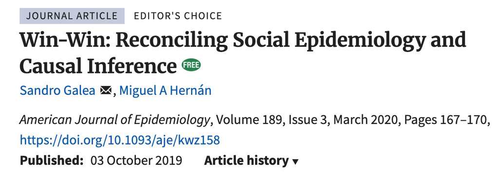

What were the main arguments?

**Move to the right of the proposed spectrum of social exposures**

[figure not shown]

Figure 1 in (Galea and Hernán 2020)

## Responses to Galea & Hernan (2019)

### Responses concerning the consistency assumption for social exposures

1. Robinson and Bailey (2020)
   - Causal effect estimation is not the only goal of social epi
     - (Preliminary) evidence to “establish or rule out causation”
       - “Can genetic differences explain racial disparities?”
     - Changes are driven by basic beliefs & narratives about causality, cultural values, attribution of moral responsibility rather than precise quantitative estimates
   - Can fall into the “reductionism trap”
     - Finding “spiders” vs victim blaming (Krieger 1994)
2. Jackson and Arah (2020)
   - System preserving
   - Systems and effect

## Responses to Galea & Hernan (2019)

3. VanderWeele (2020)
   - Quantitative potential-outcome framework for social exposures on the “left end”

**Alternative approaches for ill-defined social exposures**

1. Redefine the exposure (to make modifiability more explicit)
2. Changing interpretation
3. Shifting the target of interventions

## Approach 1: Redefining Exposures

- The effect of “race”
  - Hypothetical intervention?
  - Changing skin color? Label assigned at birth?
  - Race as a social construct
    - Racism, discrimination, perceptions
      - e.g., White-sounding names got more interviews (Bertrand and Mullainathan 2004)
- Not saying we should avoid studies of “race”
  - Quantitative causal inference as a tool is more useful for well-defined exposures

## Approach 2: Changing Interpretation

- Social participation $A=1$ (vs no participation: $A=0$)
  - Version 1: ≥ once a week ($K(1)=1$)
  - Version 2: less often ($K(1)=2$)

**Possible interpretations**

1. Effect of “assigning” a compound treatment
   - $E[Y^{1}-Y^{0}]$
2. Weighted average of version-specific effects $Y^{a,k^a}$
   - $\sum{E[Y^{a,k^a}|A=a, K^a(a)=k^a]}{Pr[K^a(a)=k^a|A=a]}$
     - *Proposition 3* in (VanderWeele and Hernan 2013)
       - Additional conditioning on $L$ in observational studies
3. Effect of assigning a random draw from versions $K$
   - From observed distribution among $A=1$ vs $A=0$
     - & Further conditioning on $L=l$ if confounding was adjusted

## Approach 3: Shifting the Target of Interventions

[figure not shown]

- The effect of SES on mitigating the racial disparity (VanderWeele and Robinson 2014)
  - What is the remaining association between race and the outcome, after manipulating SES?
  - Often viewed as an extension of mediation
    - But does not require the conceptualization of an effect for the “exposure”

## Critiques on Potential-Outcome-Based Causal Inference

[figure not shown]

What were the main arguments?

1. Need for pluralism to seek causality and explanation
   - Triangulating various types of evidence
2. “Missing tales” in a DAG
   - Accountability (e.g., pellagra)
   - Biologial explanations (e.g., birthweight paradox)
   - Modifiability (e.g., race vs racism)
1. Need for pluralism to seek causality and explanation
   - Triangulating various types of evidence
     - Sure. Not every science needs to use the potential outcome framework (and conceptualize hypothetical interventions).
     - But it is helpful when doing effet estimation
       - Gain actionable insights, prevent biases, and avoid comparing apples and oranges
2. “Missing tales” in a DAG
   - Accountability (e.g., pellagra)
     - Is this an issue of the tool itself or how you use it?
     - Theories shape hypotheses and methods
   - Biologial explanations (e.g., birthweight paradox)
     - Sure. Isn’t it another study (with a separate DAG)?
   - Modifiability (e.g., race vs racism)
     - Saying “ill-defined” does not mean negating the presence of racism

> One alarming feature of late 20th and current 21st century epidemiological literature on ‘causal inference’ is the re-appearance of previously rebutted causal claims that ‘race’ is an individual ‘attribute’ and that it cannot be a ‘cause’ because is not ‘modifiable’. (Krieger and Davey Smith 2016)

> Part of the challenge of interpreting race coefficients causally is that, in the formal causal inference literature, effects are often defined in terms of counterfactual or potential outcomes, which are defined as the outcomes that would result under hypothetical interventions. There are, however, no reasonable hypothetical interventions on race when race itself is the exposure. (VanderWeele and Robinson 2014)

> In other contexts, if we were interested in assessing race as an indicator of discrimination, we might define the exposure of interest to be the employer’s perception of an applicant’s race. The exposure defined in this manner is subject to conceivable manipulations (VanderWeele and Robinson 2014)

## Finding Common Ground (My Take)

- Many approaches for causality and explanation
  - (Quantitative) causal inference as a “tool” for effect estimation
    - Theories affect its usage (accountability and agents)
- Causal effect estimation is more meaningful and rigorous with the conceptualization of hypothetical interventions
  - Always imperfect and more challenging for social exposures
    - Does not mean we do not need to try
    - “Causes do not cease being causes if they are challenging to study or to address.” (Krieger and Davey Smith 2016)

**Recommendation**

- Read (Krieger and Davey Smith 2016) and (Galea and Hernán 2020), along with the accompanied commentaries, while distinguishing
  - Causal effect estimation vs causation
  - Issues of the tool vs its usage

## Summary 1

- Consistency assumption is often challenging for social exposures
  - Unclear actions, lack of transportability, ill-informed study design
- In general, aim for well-defined & manipulable exposures
  - Imagine hypothetical interventions
  - (Perhaps less intuitive) interpretation available even when there are multiple versions
- But ask fundamental questions: What are the spiders?
  - Cutting the “web of causation” isn’t sufficient
  - The closer we get to the spiders, the less well-defined?
    - What is the goal of your “causal analysis”? Effect estimation or explanation?

## Identification

[figure not shown]

- Consistency
- Conditional exchangeability
  - “Fair comparison” within strata of covariates $L$
  - How do we select $L$?

## Approaches to Covariate Selection

- Conventional definition
  - associated with the exposure, associated with the outcome, not on a causal pathway
- Directed Acyclic Graph (DAG)

[figure not shown]

1. Covariates to condition on
   - Common cause
     - Confounding

[figure not shown]

2. Covariates NOT to condition on
   - Mediator
   - Collider (common effect)
     - Selection bias

## Domain Knowledge and Covariate Selection

[figure not shown]

- Backdoor path criterion
  - A sufficient set of covariates to close the open path
    - $L_1$ OR $L_2$
  - Requires full knowledge of the causal structure
- Disjunctive cause criterion
  - “any pre-exposure covariate that is a cause of the exposure, or the outcome, or both” (VanderWeele 2019)
    - $L_1$ AND $L_2$
      - Check the caveats in the VanderWeele paper

**Key Considerations in Confounder Selection**

1. Which covariates
2. When

## Confounder Selection and Time

- Logitudinal analysis
  - With “baseline” covariate adjustment
  - e.g., Association between baseline social isolation and all-cause mortality, adjusting for baseline depression

[figure not shown]

**Contemporaneous measurement of an exposure and covariates**

- No clear temporal ordering

## Pre-baseline Covariates

[figure not shown]

- Clear temporal ordering
  - But residual confounding with a longer interval
    - e.g., Mental health in early adulthood as a confounder of the association between late-life social isolation and mortality

[figure not shown]

- Adjusting pre-baseline outcome & exposure values
  - Pre-baseline outcome ($Y_0$)
    - Reverse causation
    - via study design (e.g., restriction) or analytically
  - Pre-baseline exposure ($A_0$)
    - Unmeasured confounders ($U$) that have no direct influence on $A_1$ conditional on $A_0$
      - i.e., the dotted arrow is absent

## Data-Driven Covariate Selection

- “The change-in-coefficient approach”
  - Never do this
  - Confounder, mediator, collider, random chance, non-collapsibility
- Other data-driven methods
  - Potentially useful if you have a complete adjustment set $L$
    - Identification: $E[Y^a|L]=E[Y|A=a,L]$
  - Dimension reduction for better prediction of $E[Y|A, L]$
    - e.g., SuperLearner (Smith et al. 2022)
    - Not that data can tell you which covariates meet the conditional exchangeability assumption

## Interpreting Regression Estimates for Covariates

### Example: Effect of physical activity on systolic blood pressure among the NHANES sample

```r
pacman::p_load(tidyverse, broom, gtsummary, tinytable, NHANES) # load packages
# Using regression
#theme_gtsummary_compact()
NHANES |>
  mutate(poverty.bin = ifelse(Poverty <= 1, 1, 0)) |>
  lm(formula = BPSysAve ~ PhysActive + Age + Gender + poverty.bin) |>
  tbl_regression()
```

| **Characteristic** | **Beta** | **95% CI**<sup>1</sup> | **p-value** |
| --- | --- | --- | --- |
| PhysActive |  |  |  |
| No | — | — |  |
| Yes | -0.30 | -1.0, 0.40 | 0.4 |
| Age | 0.42 | 0.40, 0.44 | <0.001 |
| Gender |  |  |  |
| female | — | — |  |
| male | 4.6 | 4.0, 5.3 | <0.001 |
| poverty.bin | 2.2 | 1.3, 3.1 | <0.001 |

<sup>1</sup> CI = Confidence Interval

- $\beta_1=-0.30$
  - $E[Y|A=Yes,L]-E[Y|A=No,L]$
  - Interpretation as $E[Y^{a=Yes}|L]-E[Y^{a=No}|L]$
    - Under the conditional exchangeability for $A$
- $\beta_3=4.6$
  - $E[Y|L_2=male,A,L_1,L_3]-E[Y|L_2=female,A,L_1,L_3]$
  - “Effect of gender”?
    - Exchangeability for $L_2$ conditional on $A$, $L_1$, and $L_3$?
      - Often not met (Table 2 fallacy)

## Table 2 Fallacy

### “Risk factor” analysis of COVID-19-related death

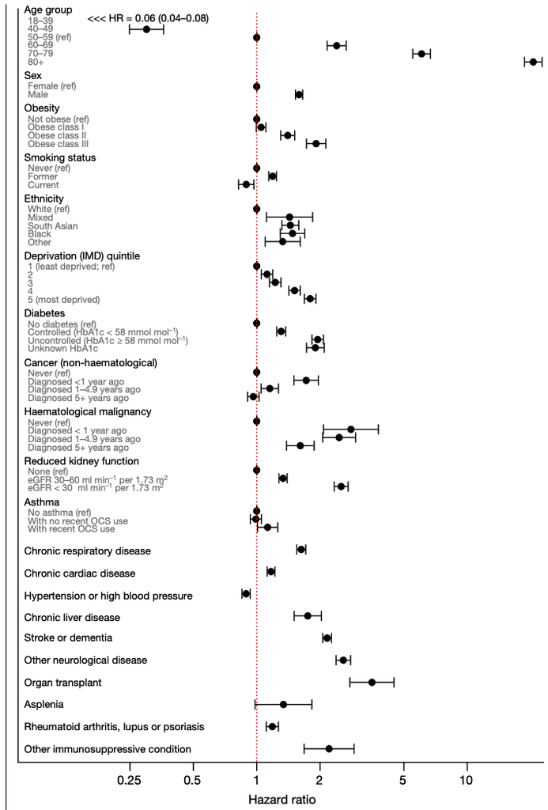

- Nature article (Williamson et al. 2020)
  - Multivariable Cox regression of COVID-19-related mortality on numerous “risk factors”
  - Presented estimates as if causal
    - “South Asian and Black people had a substantially higher risk of COVID-19-related death than white people, and this was only partly attributable to comorbidities, deprivation or other factors.”
  - HR for current smoking (vs never): 0.89
    - Protective effect or Table 2 fallacy??

## Conditional Exchangeability Assumption in Practice

### An epidemiologist’s delusion?

[figure not shown]

- Never achieved perfectly with observational data
  - Can never be verified empirically
  - The cliché: “We cannot preclude the possibility of bias due to unmeasured confounders”

**What to do instead of giving up**

1. Critical (yet constructive) evaluation
   - Bias analysis
   - Falsification
2. Alternative assumptions

## Bias Analysis

### Qualitative

- Unmeasured confounders are inevitable
- Acknowledge the potential bias
  - Be specific
- Not a binary problem
  - Direction?
    - Conservative?
  - Magnitude?

Is the potential bias critical conditional on the adjusted confounders?

[figure not shown]

“Confounding by income, after adjusting for age, gender, race, education, occupation, median income of census tract of residence?”

## Bias Analysis

### Quantitative

1. How big would the bias be?
   - By specifying bias parameters for an unmeasured confounder
     - Quantitative bias analysis (Fox et al. 2021)
2. How strong the bias would need to be?
   - To explain away the observed association
   - Associations of a confounder with an exposure/outcome
     - E-value (VanderWeele and Ding 2017)

[figure not shown]

Interpret these analyses conditional on the adjusted confounders?

## Falsification

- We can never verify conditional exchangeability
- But we can attempt to falsify the assumption
  - Try to observe what you would expect to see under non-exchangeability
    - Alternative exposure-outcome relationships that (you think) have no effect
      - Negative control (Lipsitch et al. 2010)

**Statistical associations for no effect**

- If observed, major violation
- If not observed, more confidence in the assumption
  - Not verification of the assumption

## Falsification: Example

[figure not shown]

- The association between eating organic foods and health
  - Adjusted for many confounders
  - Remaining concern of unmeasured confounders $U$
    - e.g., health-consciousness, wealth

[figure not shown]

- “The effect on having perfectly aligned teeth”
  - In theory, no effect
  - Similar confounding structure
- Association after adjusting for the observed ones?
  - If yes, suggest unadjusted confounding
  - If no, does not guarantee conditional exchangeability
    - But perhaps more confidence?

## Falsification: Example

- Comparing two mRNA COVID-19 vaccine groups (Dickerman et al. 2022)
  - Differences in COVID-related outcomes
    - e.g., infection
  - Matched on observed covariates
    - If no confounding, when do these two groups should have the same outcome?

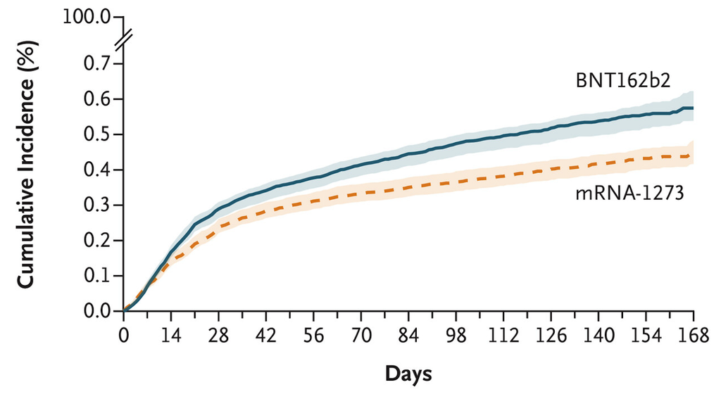

Incidence in the first 10 days after the first shot

[figure not shown]

Deaths unrelated to Covid-19

[figure not shown]

## Summary 2

- Covariate selection
  - Drawing a DAG or more practical approaches
    - Requires domain knowledge to begin
    - Generally, no conditional exchangeability for covariates (Table 2 fallacy)
  - Temporality
    - Pre-baseline covariates
      - Pre-baseline exposure and outcome values
- Embrace the painful fact of “unmeasured confounders”
  - Bias analysis
    - Interpretation conditional on adjusted covariates
  - Falsefication (not verification) of the assumption

## Conditional Exchangeability Assumption in Practice

### An epidemiologist’s delusion?

[figure not shown]

- Never achieved perfectly with observational data
  - Can never be verified empirically
  - The cliché: “We cannot preclude the possibility of bias due to unmeasured confounders”

**What to do instead of giving up**

1. Critical (yet constructive) evaluation
   - Bias analysis
   - Falsification
2. Alternative assumptions

## Alternative Assumptions: Approach 1

- Standard approach
  - Compare outcome values between groups with different exposure levels
  - Between-person comparison
    - People have different backgrounds (i.e., confounding)
      - *Time-invariant*: genes, biological sex, (perhaps personality/educaton)
      - *Time-varying*: income, depressive symptoms

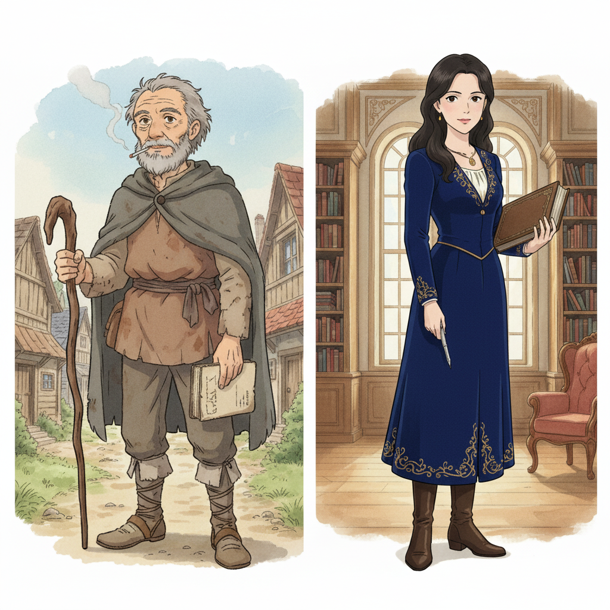

- Within-person comparison
  - Focus on changes within the same individuals
    - Fixed-effect analysis
  - Control for ALL time-invariant confounders
    - Including unobserved ones
      - Time-invariant: no change during the same time period
    - Still susceptible to confounding by time-varying confounders (e.g., income)

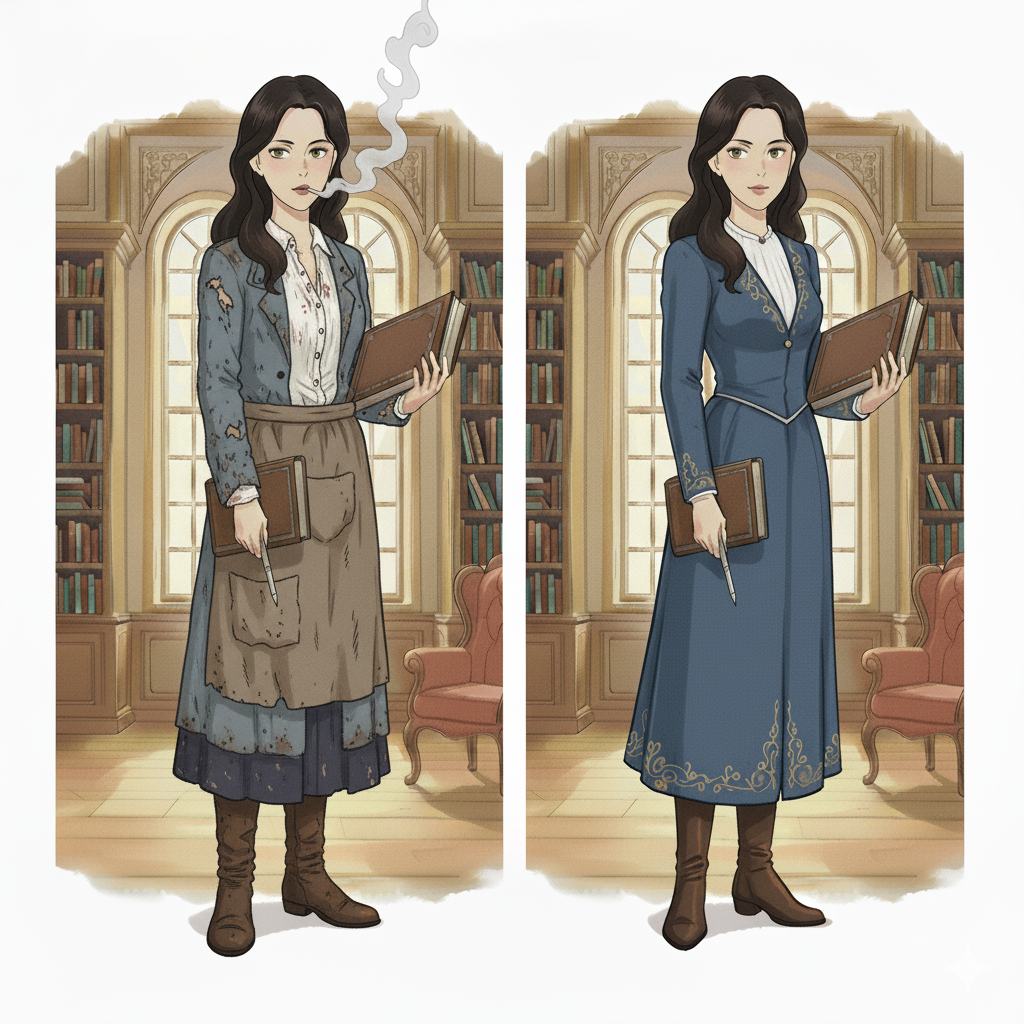

## Fixed-Effect Analysis

- Use panel data with multiple waves
  - So you can observe changes in exposure, outcome, covariates for the same individuals
    - Two common analytical approaches
1. “Change-on-change” model
   - $E[\Delta Y_{it}|\Delta A_{it}, \Delta L_{it}]=\beta_0 + \beta_1 \Delta A_{it} + \beta \Delta L_{it}$
     - $\Delta Y_{it}=Y_{it}-Y_{it-1}$ (a.k.a. first-difference method)
     - or use “de-meaned data”: $\tilde Y_{it}=Y_{it}-\bar Y_{i}$

| ID (i) | Time (t) | $Y_{it}$ | $A_{it}$ | $L_{it}$ |
| --- | --- | --- | --- | --- |
| 1 | 1 | 100 | 10 | 20 |
| 1 | 2 | 110 | 12 | 22 |
| 1 | 3 | 125 | 15 | 25 |
| 2 | 1 | 80 | 8 | 15 |
| 2 | 2 | 85 | 9 | 16 |
| 2 | 3 | 95 | 11 | 18 |

| ID (i) | Time (t) | $\Delta Y_{it}$ | $\tilde{Y}_{it}$ | $\Delta A_{it}$ | $\tilde{A}_{it}$ |
| --- | --- | --- | --- | --- | --- |
| 1 | 1 | - | -11.67 | - | -2.33 |
| 1 | 2 | 10 | -1.67 | 2 | -0.33 |
| 1 | 3 | 15 | 13.33 | 3 | 2.67 |
| 2 | 1 | - | -6.67 | - | -1.33 |
| 2 | 2 | 5 | -1.67 | 1 | -0.33 |
| 2 | 3 | 10 | 8.33 | 2 | 1.67 |

## Fixed-Effect Analysis

2. Individual dummy variables

| ID (i) | Time (t) | $Y_{it}$ | $A_{it}$ | $L_{it}$ |
| --- | --- | --- | --- | --- |
| 1 | 1 | 100 | 10 | 20 |
| 1 | 2 | 110 | 12 | 22 |
| 1 | 3 | 125 | 15 | 25 |
| 2 | 1 | 80 | 8 | 15 |
| 2 | 2 | 85 | 9 | 16 |
| 2 | 3 | 95 | 11 | 18 |

- Regression for person-time data
  - Adjusting for individual dummies as a covariate
  - $E[Y_{it}|A_{it},L_{it}, D_i]=\beta_0 + \beta_1 A_{it} + \beta L_{it} + \gamma D_i$
    - $D_i$ for $ID_i=1,....,n-1$
- $\beta_1$: a confounder-adjusted exposure-outcome association
  - Conditional on individual IDs
    - Within the same individual
    - Eliminate confounding by confounders that did not change between $t-1$ and $t$

## Fixed-Effect Analysis

**Caveats**

1. Temporal ordering
   - Within-individual changes in exposure and outcome
     - Which change occurred first?
       - Reverse causation
       - Lagged model (e.g., regress $Y_{i,t+1}-Y_{i, t}$ on $A_{i,t}-A_{i, t-1}$)
2. Time interval
   - Short-term changes
     - Lack of variations for relatively stable exposures
     - Capture immediate effects
   - Long-term changes
     - Greater risks of time-varying confounders

## Alternative Assumptions: Approach 2

- Quasi experimental approaches
  - Use (plausibly) random exposure variations
    - Many of the “econometric” methods
    - Instrumental variable, regression discontinuity, interrupted time series
      - Often viewed as “superior” causal inference

**Not necessarily “superior” as they use:**

- Different assumptions
- Different target population (hence, different estimand)

## Instrumental Variable

[figure not shown]

- Effect of participating in community gathering places ($A$) on functional disability ($Y$) (Hikichi et al. 2015)
  - Many confounders ($U$)
  - The number of gathering places within a radius of 350m from each respondent’s home ($Z$)
    - which affects participation ($A$)

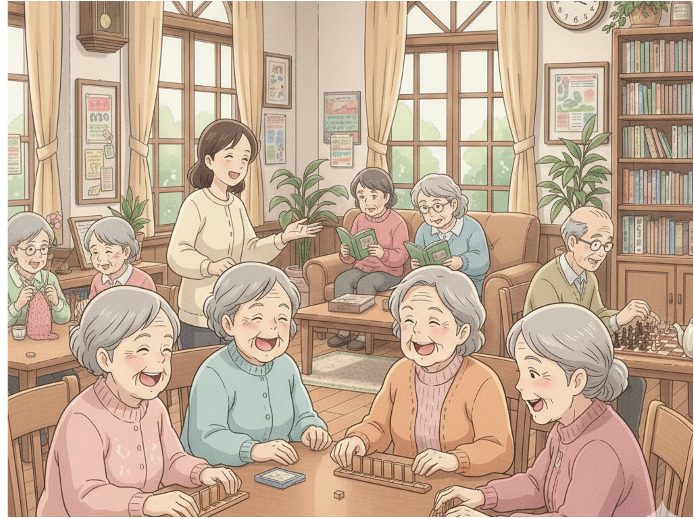

## Instrumental Variable

[figure not shown]

- Effect of participating in community gathering places ($A$) on functional disability ($Y$) (Hikichi et al. 2015)
  - Many confounders ($U$)
  - The number of gathering places within a radius of 350m from each respondent’s home ($Z$)
    - which affects participation ($A$)

**The effect of $A$ on $Y$ can be identified when:**

1. $Z$ is correlated with $A$
2. $Z$ affects $Y$ only through $A$
   - No direct effect of $Z$ on $Y$ (i.e., absence of the dotted arrow)
3. Exchangeability for the relationship between $Z$ and $Y$ (conditional on $L$)
   - Replacing (conditional) exchangeability assumption
     - with extra assumptions
     - may or may not be more plausible

## Instrumental Variable: The Fourth Assumption

- Counterfactual exposure values ($A$) under an intervention for a proposed instrument ($Z=z$)
  - $A^z$
    - Not observable

Types of $A^z$ for binary $A$ and $Z$

| Type | $A^{z=0}$ | $A^{z=1}$ | Behavior |
| --- | --- | --- | --- |
| Never-takers | 0 | 0 | Never exposed regardless of $Z$ |
| Compliers | 0 | 1 | Exposed only when $Z=1$ |
| Always-takers | 1 | 1 | Always exposed regardless of $Z$ |
| Defiers | 1 | 0 | Would do opposite |

4. Monotonicity assumption
   - There is no “defiers”
     - If $z < z^*$ then $A_i^z \le A_i^{z^*}$ for all $i$
     - Intuition: There are no individuals who would do the opposite of what the instrument “encourages”
- Under the monotonicity assumption, the instrument $Z$ allows the estimation of effect $A$ on $Y$ among “compliers”
  - Who are they? External validity?

## Regression Discontinuity Design (RDD)

### Example: Effect of attending an elite university ($A$) on earning ($Y$) (Hoekstra 2009)

- Those who got admitted vs those who did not
  - Confounding
- Probability of admission “jumps” at the cutoff test score ($X=50$)
  - $\Delta Pr[A=1|X=50]=\lim_{x \leftarrow 50} Pr[A=1]- \lim_{x \to 50} Pr[Y=1]$
    - Applicants just below vs above the cutoff are similar?
      - Random variation in the treatment $A$ (a special case of the instrumental variable approach)

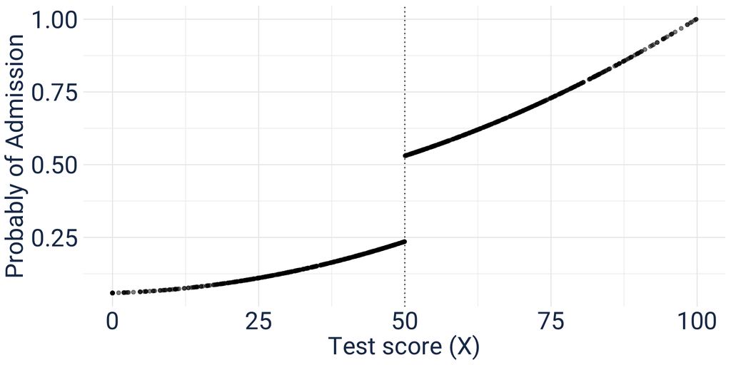

```r
# simulate the data
dat <- tibble(
  x = rnorm(1000, 50, 25)
) %>%
  mutate(
    x = if_else(x < 0, 0, x)
  ) %>%
  filter(x < 100)

# simulate the discontinuity
dat <- dat %>%
  mutate(
    D  = if_else(x > 50, 1, 0), # cutoff at x = 50
    y = 25 + 300 * D + 0.1 * x + 0.1 * x^2 + rnorm(n(), 0, 50),
    y = y/max(y)*100,
    PS = 0.1 + 0.5 * D + 0.001 * x + 0.0001 * x^2,
    PS = PS/max(PS)
  )

ggplot(aes(x, PS), data = dat) +
  geom_point(alpha = 0.5) +
  geom_vline(xintercept = 50, linetype = "dotted") +
  labs(x = "Test score (X)", y = "Probably of Admission") +
  theme_minimal() +
  theme(text = element_text(family = "roboto",size = 24, , colour = "#1d3557"),
        axis.text = element_text(family = "roboto",size = 24, colour = "#1d3557")
        )
```

## Regression Discontinuity Design (RDD)

- Difference in $Y$ *at the cutoff*
  - $\Delta E[Y|X=50] = \lim_{x \leftarrow 50}E[Y]- \lim_{x \to 50} E[Y]$
  - Assumption: Applicants just below vs above the cutoff are similar
    - Attributable to the difference in (the probability of) college admission

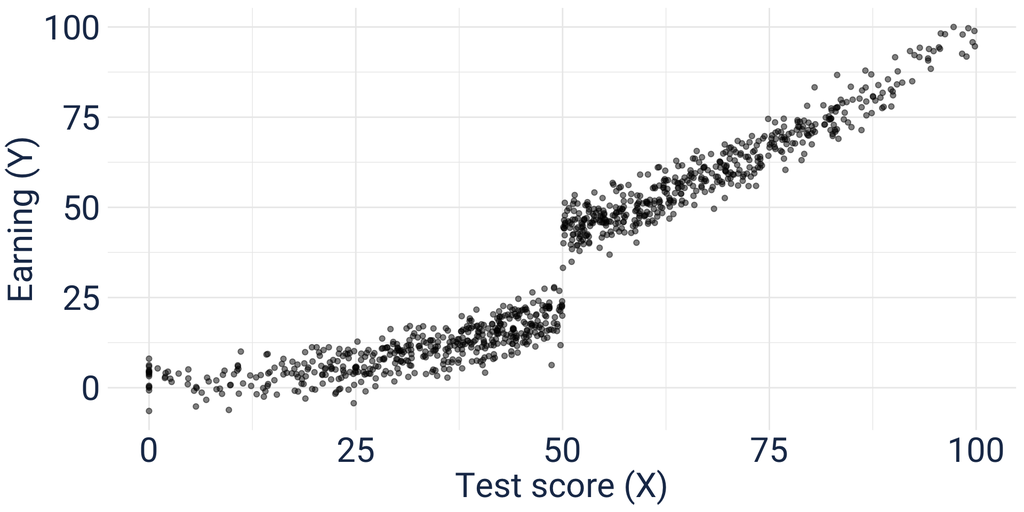

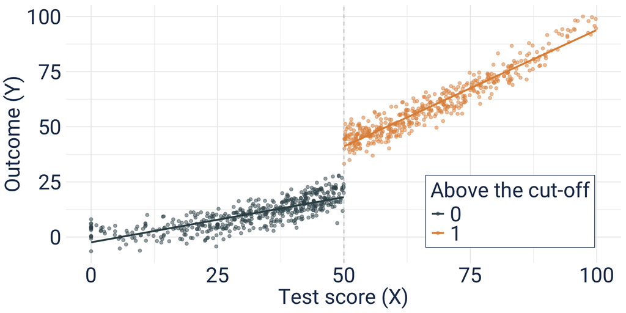

```r
# figure
ggplot(aes(x, y), data = dat) +
  geom_point(alpha = 0.5) +
  labs(x = "Test score (X)", y = "Earning (Y)") +
  theme_minimal() +
  theme(text = element_text(family = "roboto",size = 24, , colour = "#1d3557"),
        axis.text = element_text(family = "roboto",size = 24, colour = "#1d3557")
        )
ggplot(aes(x, y, colour = factor(D)), data = dat) +
  geom_point(alpha = 0.5) +
  geom_vline(xintercept = 50, colour = "grey", linetype = 2) +
  ggsci::scale_color_jama(name = "Above the cut-off") +
  stat_smooth(method = "lm", se = F) +
  labs(x = "Test score (X)", y = "Outcome (Y)") +
  theme_minimal() +
  theme(text = element_text(family = "roboto",size = 24, , colour = "#1d3557"),
        axis.text = element_text(family = "roboto",size = 24, colour = "#1d3557"),
        legend.text = element_text(family = "roboto",size = 24, colour = "#1d3557"),
        legend.title = element_text(family = "roboto",size = 24, colour = "#1d3557"),
        legend.position = "inside",
        legend.position.inside = c(0.8, 0.2),
        legend.box.background = element_rect(colour = "#1d3557"))
```

- $\Delta E[Y|X=50] / \Delta Pr[A=1|X=50]$
  - The effect of admission on earning at the cut-off among compliers
  - Local average treatment effect (LATE)

## Summary 3

- Between-person comparison
  - Unmeasured confounders but flexible
- Within-person comparison
  - Time-varying confounders
  - Data limitation, lack of variation, short-term effect
- Quasi experimental
  - Alternative assumptions
    - Still not verifiable
    - Not always feasible
  - Different and vague target population (e.g., compliers)
    - External validity issue
    - When results are different from the covariate-adjsutment approaches
      - More rigorous causal inference?
      - Comparing 🍎 and 🍊?

## Assignment

- Problem set #3
- Reading quiz based on:
  1. Arcaya MC, Tucker-Seeley RD, Kim R, Schnake-Mahl A, So M, Subramanian SV. Research on neighborhood effects on health in the United States: a systematic review of study characteristics. Social science & medicine. 2016 Nov 1;168:16-29.
  2. Oakes JM, Rossi PH. The measurement of SES in health research: current practice and steps toward a new approach. Social science & medicine. 2003 Feb 1;56(4):769-84.

## References

Bertrand M, Mullainathan S. Are emily and greg more employable than lakisha and jamal? A field experiment on labor market discrimination. American economic review. 2004;94(4):991–1013.

Dickerman BA, Gerlovin H, Madenci AL, Kurgansky KE, Ferolito BR, Figueroa Muñiz MJ, et al. Comparative effectiveness of BNT162b2 and mRNA-1273 vaccines in US veterans. New England Journal of Medicine. 2022;386(2):105–15.

Fox MP, MacLehose RF, Lash TL. Applying quantitative bias analysis to epidemiologic data. Vol. 10. Springer; 2021.

Galea S, Hernán MA. Win-win: Reconciling social epidemiology and causal inference. American journal of epidemiology. 2020;189(3):167–70.

Hikichi H, Kondo N, Kondo K, Aida J, Takeda T, Kawachi I. Effect of a community intervention programme promoting social interactions on functional disability prevention for older adults: Propensity score matching and instrumental variable analyses, JAGES taketoyo study. J Epidemiol Community Health. 2015;69(9):905–10.

Hoekstra M. The effect of attending the flagship state university on earnings: A discontinuity-based approach. The review of economics and statistics. 2009;91(4):717–24.

Jackson JW, Arah OA. Invited commentary: Making causal inference more social and (social) epidemiology more causal. American journal of epidemiology. 2020;189(3):179–82.

Krieger N. Epidemiology and the web of causation: Has anyone seen the spider? Social science & medicine. 1994;39(7):887–903.

Krieger N, Davey Smith G. The tale wagged by the DAG: Broadening the scope of causal inference and explanation for epidemiology. International journal of epidemiology. 2016;45(6):1787–808.

Lipsitch M, Tchetgen ET, Cohen T. Negative controls: A tool for detecting confounding and bias in observational studies. Epidemiology. 2010;21(3):383–8.

Robinson WR, Bailey ZD. Invited commentary: What social epidemiology brings to the table—reconciling social epidemiology and causal inference. American journal of epidemiology. 2020;189(3):171–4.

Smith MJ, Mansournia MA, Maringe C, Zivich PN, Cole SR, Leyrat C, et al. Introduction to computational causal inference using reproducible stata, r, and python code: A tutorial. Statistics in medicine. 2022;41(2):407–32.

VanderWeele TJ. Principles of confounder selection. European journal of epidemiology. 2019;34(3):211–9.

VanderWeele TJ. Invited commentary: Counterfactuals in social epidemiology—thinking outside of “the box.” American Journal of Epidemiology. 2020;189(3):175–8.

VanderWeele TJ, Ding P. Sensitivity analysis in observational research: Introducing the e-value. Annals of internal medicine. 2017;167(4):268–74.

VanderWeele TJ, Hernan MA. Causal inference under multiple versions of treatment. Journal of causal inference. 2013;1(1):1–20.

VanderWeele TJ, Robinson WR. On the causal interpretation of race in regressions adjusting for confounding and mediating variables. Epidemiology. 2014;25(4):473–84.

Williamson EJ, Walker AJ, Bhaskaran K, Bacon S, Bates C, Morton CE, et al. Factors associated with COVID-19-related death using OpenSAFELY. Nature. 2020;584(7821):430–6.